# Final Project Data Product

Marco Guado

September 15, 2016

# Resumen

The Shiny application to be developed is based on the final project (1) presented in machine learning course. This project is to implement a model to predict what the best routine to perform an exercise with weights.  
(1) url Project used machine learning [final] (http://htmlpreview.github.io/?https://github.com/magzupao/machine_learning/blob/master/project_machine_learning_magz.html)

# Modelo

Our initial model consists of 5 measurements recorded by sensors placed; wrist, forearm and arm several people. Where A is better and E is the worst routine.

Classification:  
A  
B  
C  
D  
E

It was recorded for each user samples were grouped in a matrix composed of data of 160 variables and 19622 records.

# Process

After processing (data cleaning) the model, we have a data matrix consisting of 53 variables and records 19622. where we have:  
52 -> variables predictors  
1 -> variable discriminant  
Based on the analysis model where we have quantitative and qualitative variables can solve a case prediction algorithm using the Random Forest.

# Results

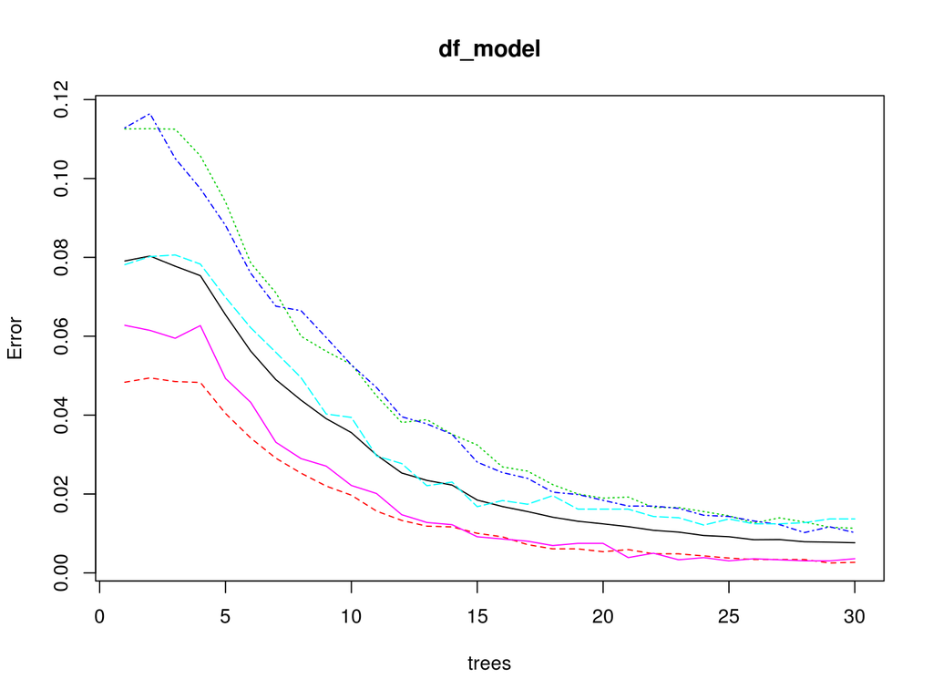